# Forming a Network from Emails at a Large European Research Institution

Kelly Ng

3/18/2022

I need the following packages for this project:

```r
library(tidyverse)
library(tidygraph)
library(ggraph)
library(igraph)
```

### 1. Importing data (as tibbles):

```r
eu_nodes <- read_table(
  "email-Eu-core-department-labels.txt.gz",
  col_names = c("person", "dept")
)

eu_edges <- read_table(
  "email-Eu-core.txt.gz",
  col_names = c("from", "to")
)
```

### 2. Cleaning up the data by adding 1 to every person identifier (instead of it being 0).

```r
eu_nodes <- mutate(eu_nodes, person = person + 1)

eu_edges <- eu_edges + 1
```

### 3. Creating `tbl_graph` from the data.

```r
eu_netw <-
  tbl_graph(nodes = eu_nodes, edges = eu_edges) |>
  print()
```

```
## # A tbl_graph: 1005 nodes and 25571 edges
## #
## # A directed multigraph with 20 components
## #
## # Node Data: 1,005 × 2 (active)
##   person  dept
##    <dbl> <dbl>
## 1      1     1
## 2      2     1
## 3      3    21
## 4      4    21
## 5      5    21
## 6      6    25
## # … with 999 more rows
## #
## # Edge Data: 25,571 × 2
##    from    to
##   <int> <int>
## 1     1     2
## 2     3     4
## 3     3     5
## # … with 25,568 more rows
```

### 4. Initial plot of the complete network.

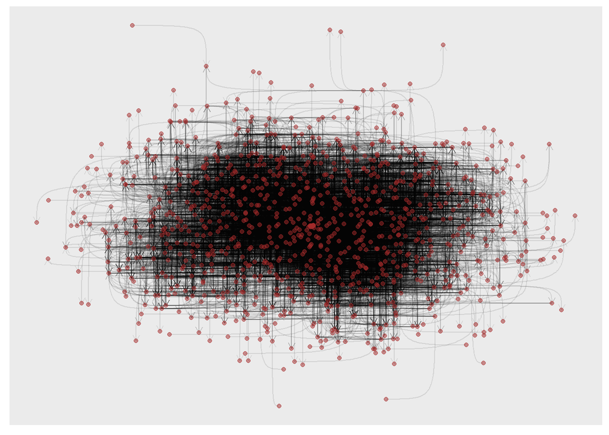

```r
ggraph(eu_netw, layout = "kk") +
  geom_edge_bend(
    alpha = 0.1,
    arrow = arrow(length = unit(2, "mm"))
  ) +
  geom_node_point(colour = "brown", alpha = 0.5)
```

```r
contracted_eu_igraph <-
  eu_netw |>
  as.igraph() |>
  contract(eu_nodes$dept + 1)
vertex_attr(contracted_eu_igraph, "dept") <-
  0:(gorder(contracted_eu_igraph) - 1)
contracted_directed_netw <-
  as_tbl_graph(contracted_eu_igraph) |>
  convert(to_simple) |>
  activate(edges) |>
  mutate(weight = lengths(.tidygraph_edge_index)) |>
  print()
```

```
## # A tbl_graph: 42 nodes and 1203 edges
## #
## # A directed simple graph with 1 component
## #
## # Edge Data: 1,203 × 5 (active)
##    from    to .tidygraph_edge_index .orig_data         weight
##   <int> <int> <list>                <list>              <int>
## 1     1     2 <int [35]>            <tibble [35 × 2]>      35
## 2     1     3 <int [1]>             <tibble [1 × 2]>        1
## 3     1     4 <int [8]>             <tibble [8 × 2]>        8
## 4     1     5 <int [123]>           <tibble [123 × 2]>    123
## 5     1     6 <int [26]>            <tibble [26 × 2]>      26
## 6     1     7 <int [5]>             <tibble [5 × 2]>        5
## # … with 1,197 more rows
## #
## # Node Data: 42 × 2
##    dept .tidygraph_node_index
##   <int>                 <int>
## 1     0                     1
## 2     1                     2
## 3     2                     3
## # … with 39 more rows
```

### 6. Making a plot of the contracted network.

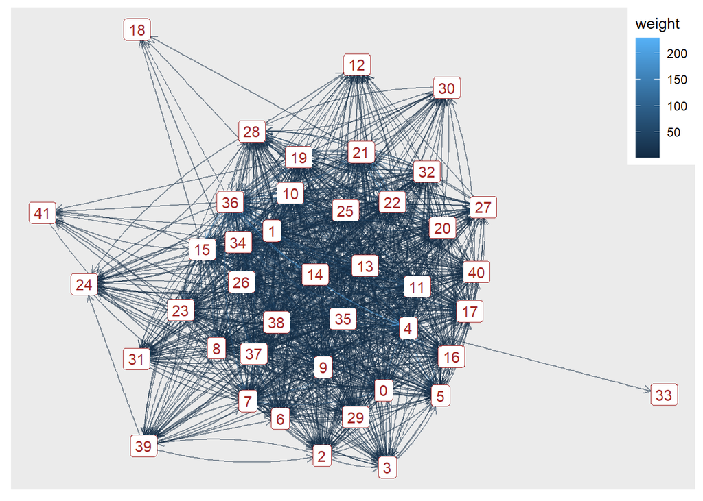

```r
ggraph(contracted_directed_netw, layout = "stress") +
  geom_edge_fan(
    aes(colour = weight, end_cap = label_rect(node2.dept)),
    alpha = 0.5,
    arrow = arrow(length = unit(0.2, "cm"))
  ) +
  geom_node_label(aes(label = dept), colour = "brown") +
  theme(legend.position = c(1, 1), legend.justification = c(1, 1))
```

This result is not very useful because there are too many edges (lines) connected the nodes that it produces an illegible plot, where readers don’t know what is connected to what. However, it is useful knowing the positions of the nodes relative to each other (i.e., 33 node is further away).

### 7. Visualizing the data as a dendrogram that shows how close relations between departments are.

```r
undirected_simple_netw <-
  contracted_directed_netw |>
  convert(to_undirected) |>
  convert(to_simple) |>
  activate(edges) |>
  mutate(weight = map_int(.orig_data, ~ sum(.$weight))) |>
  print()
```

```
## # A tbl_graph: 42 nodes and 641 edges
## #
## # An undirected simple graph with 1 component
## #
## # Edge Data: 641 × 5 (active)
##    from    to .tidygraph_edge_index .orig_data       weight
##   <int> <int> <list>                <list>            <int>
## 1     1     2 <int [2]>             <tibble [2 × 4]>     54
## 2     1     3 <int [2]>             <tibble [2 × 4]>      3
## 3     1     4 <int [2]>             <tibble [2 × 4]>     17
## 4     1     5 <int [2]>             <tibble [2 × 4]>    273
## 5     1     6 <int [2]>             <tibble [2 × 4]>     48
## 6     1     7 <int [2]>             <tibble [2 × 4]>     16
## # … with 635 more rows
## #
## # Node Data: 42 × 2
##    dept .tidygraph_node_index
##   <int>                 <int>
## 1     0                     1
## 2     1                     2
## 3     2                     3
## # … with 39 more rows
```

### 8. Using the **tidygraph** function `to_hierarchical_clusters()` to obtain a new netowrk that contains the hierarchy of the dendrogram.

```r
hierarchy <-
  undirected_simple_netw |>
  convert(to_hierarchical_clusters, weights = weight)
hierarchy
```

```
## # A tbl_graph: 83 nodes and 82 edges
## #
## # A rooted tree
## #
## # Edge Data: 82 × 2 (active)
##    from    to
##   <int> <int>
## 1     4     2
## 2     4     3
## 3     8     6
## 4     8     7
## 5     9     5
## 6     9     8
## # … with 76 more rows
## #
## # Node Data: 83 × 5
##   height leaf  members .tidygraph_node_index  dept
##    <dbl> <lgl>   <int>                 <int> <int>
## 1      0 TRUE        1                    34    33
## 2      0 TRUE        1                    22    21
## 3      0 TRUE        1                    29    28
## # … with 80 more rows
```

### 9. Using `ggraph()` to plot a dendogram similar to previously.

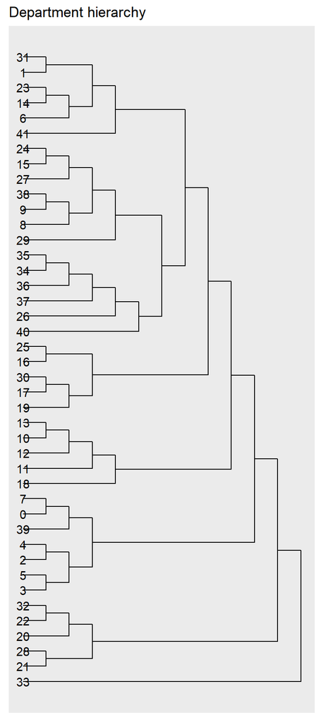

```r
layout <- create_layout(hierarchy, "dendrogram")

ggraph(layout) +
  geom_edge_elbow() +
  coord_flip() +
  geom_node_text(aes(label = dept, filter = leaf)) +
  labs(title = "Department hierarchy")
```

### Evaluating the advantages and disadvantages of representing the network data with the dendogram and network figure.

**Advantages**

- Can see clearly which node is related to which, unlike the figure in task (6) where too many lines overlapped with each other, which made it illegible.
- It’s easy to see what the clusters are present and which nodes are within each cluster.

**Disadvantages**

- On the dendrogram, we aren’t able to know which node is connected to which node, or how many edges each node has as the plot is in a hierarchical structure instead. Hence, the dendrogram needs more explanation.